# Referenciar a fragmento

# 1 Fragmento frente a documento.

Solemos referenciar a otros documentos usando enlaces (para justificar, citar referencia, o símplemente enlazar para más información). Pero dar el enlace a un documento entero muy grande es demasiado amplio, especialmente cuando nos estamos refiriendo a una parte concreta de él.

Obligas a quien te lee a hacer un gran scroll buscando visualmente la seccioń oportuna… O, alternativamente, si es más espabilado (y mucha gente no tiene esto interiorizado), le obligas a buscar dentro de la página (usando el menú para hacerlo, o usando `control+F` si está en un escritorio).

Lo ideal en estos casos es dar enlace directo al fragmento del documento específico (si el documento tiene estructura y fragmentos explícitos, que a menudo los tendrá).

Es lo que ya conocéis de los [URI fragment](https://en.wikipedia.org/wiki/URI_fragment).

Usarlos al referenciar es una parte del “trabajo” de quien referencia algo: hacerlo con precisión y facilidad para su lector.

# 2 Enlace a fragmento ofrecido explícitamente. Ej. GitHub.

En muchos casos es fácil. En muchas páginas viene nativo en el interfaz (especialmente las creadas con ciertos CMS o frameworks).

Por ejemplo en los `.md` renderizados por Github el enlace al fragmento aparece al hacer hover cerca de una sección:

[figure not shown]

Al hacer hover a la izquierda del heading, te aparece el icono:

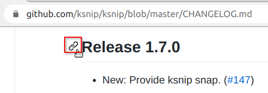

Lo puedes copiar con botón derecho, o clicando en él vas al fragmento (como se ve aquí en la barra de direcciones):

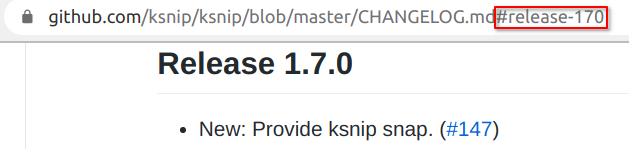

Por tanto, en este ejemplo, si nos estamos refiriendo a los cambios de una versión concreta 1.7.0, el enlace correcto a dar sería:

https://github.com/ksnip/ksnip/blob/master/CHANGELOG.md#release-170

y no el enlace a todo el documento de versiones:

https://github.com/ksnip/ksnip/blob/master/CHANGELOG.md

Por supuesto, se puede aparte mencionar que el enlace a un fragmento pertenece a cierto documento más amplio (y el interés de ese documento entero). Pero si hablamos de una zona concreta, pasamos enlace a zona concreta.

En otros sitios Web los enlaces a fragmentos pueden ser aún más intuitivos/descubribles/visibles: icono directamente visible sin necesidad de hover. Convenios habituales aquí es usar un icono que simboliza “sección” (§) o el que simboliza párrafo (¶).

Lo vemos por ejemplo en las páginas de los estándares de WHATWG (HTML5, …). Lo hace para secciones (símbolo §):

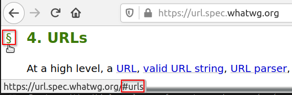

y para los ejemplos (usa símbolo ¶):

[figure not shown]

# 3 Enlaces a fragmento ofrecido en índice. Ej. Wikipedia.

Ciertos sitios no los ponen explícitos como el ejemplo anterior, pero ponen un índice a las secciones dentro de una página. Se pueden usar esos enlaces.

Por ejemplo, en una página de la Wikipedia:

[figure not shown]

1. Si queremos queremos el fragment URI hacia la sección “Basics”.
2. Lo miramos en el índice.
3. Nos muestra cuál es (y permite copiarlo).

# 4 Enlace a fragmento implícito. Ej. MDN.

En muchos otros sitios aunque no aparezcan en ningún enlace de la página explícito, aún así tiene fragmentos. Por ejemplo, en el MDN esto es una sección de un documento:

[figure not shown]

Si damos al Inspector y lo señalamos, vemos que tiene un “id”, y por tanto se puede acceder a él con fragmento:

[figure not shown]

Construyendo la URL, vemos que funciona (nos sitúa en el fragmento):

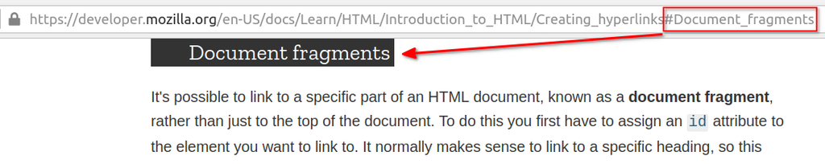

Este método que requier usar el Inspector es un poco hacker (pero nosotros somos desarrolladores).

Notamos aquí una práctica habitual de que un espacio se convierta en un guión bajo “_” en el id del fragmento.

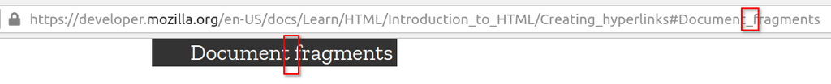

# 5 Permalink. Ej. StackExchange.

Siempre que el interfaz te lo ofrezca, es conveniente usar lo que se llama un [permalink](https://en.wikipedia.org/wiki/Permalink). Es decir, un link que se supone que será difícil que se rompa en mucho tiempo. Y en el caso de cosas con versiones (las Wikis, la Wikipedia), permite apuntar a la versión específica que estemos referenciando.

Lo vemos en el caso concreto de “StackExchange” (que engloba Stackoverflow, ServerFault y otros).

En esta pregunta precisamente alguien pregunta al respecto de cómo enlazar a una respuesta concreta:

https://meta.stackexchange.com/questions/45597/how-can-i-link-to-a-specific-answer/

En esta respuesta a esa pregunta lo explica, y de paso indica cómo referenciar un comentario concreto:

https://meta.stackexchange.com/a/242027

- Enlace a cierta respuesta:

  Copiar el enlace “share” que aparece debajo de esa respuesta.

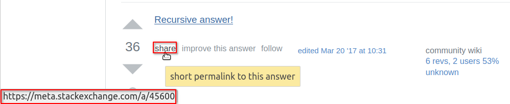

  En el ejemplo de la imagen, el permalink ofrecido es (en negrita el identificador global de la respuesta)

  Vemos que es un enlace corto:
  - Bueno para “Twitter” y similares.
  - Pero mala legibilidad/usabilidad/SEO.
- Enlace a comentario concreto (ya sea comentario a la pregunta o a una respuesta concreta):

  Copiar el enlace de la marca de tiempo.

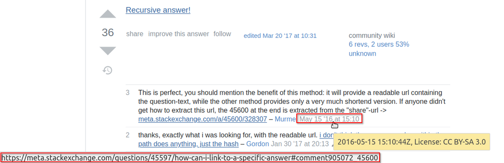

  En el ejemplo de la imagen, el enlace ofrecido es (en negrita el identificador del comentario):

  [https://meta.stackexchange.com/questions/45597/how-can-i-link-to-a-specific-answer**#comment905072_45600**](https://meta.stackexchange.com/questions/45597/how-can-i-link-to-a-specific-answer#comment905072_45600)

  Vemos que es enlace largo, incluyendo el enlace original a la pregunta y añadiendo un fragmento: mejor legibilidad/usabilidad/SEO.

Se puede construir fácilmente un enlace a una respuesta que sea largo (legibilidad/usabilidad/SEO). Lo vemos con el ejemplo anterior:

- Enlace a la pregunta:

  https://meta.stackexchange.com/questions/45597/how-can-i-link-to-a-specific-answer
- Enlace corto a cierta respuesta, obtenido por el enlace “share” (en negrita he resaltado el “id” de la respuesta):

  [https://meta.stackexchange.com/a/**45600**](https://meta.stackexchange.com/a/45600)
- Enlace largo a esa respuesta: añadimos ese “id” como fragmento a la URL de la pregunta (con `#` antes):

  [https://meta.stackexchange.com/questions/45597/how-can-i-link-to-a-specific-answer#**45600**](https://meta.stackexchange.com/questions/45597/how-can-i-link-to-a-specific-answer#45600)
- Nota:

  Hemos construido el enlace con

  `URL-SIGNIFICATIVA + # + id`

  Cuando usamos el enlace corto oficial, este se convierte en otra URL oficial que es menos compacta que la que usamos nosotros:

  `URL-SIGNIFICATIVA + / + id + # + id`

  Sale el “id” dos veces. En nuestro ejemplo, sería:

  [https://meta.stackexchange.com/questions/45597/how-can-i-link-to-a-specific-answer/**45600**#**45600**](https://meta.stackexchange.com/questions/45597/how-can-i-link-to-a-specific-answer/45600#45600)

  Ponerlo sin duplicar como propongo, es más “elegante” (y rápido), pero no es lo “canónico”. Es un “hack” (que podría dejar de funcionar más fácilmente que el enlace “canónico”).

En [otra respuesta a esta pregunta concreta](https://meta.stackexchange.com/questions/45597/how-can-i-link-to-a-specific-answer#305392) aportan un par de matices para cuando estamos registrados y logeados (cuenta en StackExchange). En ese caso:

- Los enlaces de “share” incluyen al final nuestro identificador de usuario (podemos preferir quitárselo).
- Al estar logueados, tenemos tras cada respuesta un botón de “answer” (para responder a una respuesta) aparte del de “share”. Ese enlace del “answer” es largo (legible) y permite ir directamente a esa respuesta concreta (sin necesidad de construirlo a mano como se ha mostrado antes).

# 6 Enlace a “fragmento” de vídeo/audio. Ej. Youtube.

Cuando enlazamos a un vídeo/audio, puede aplicar incluso más lo que hemos dicho para un documento: ahí el “ojear” el video entero (o escuchar el audio entero) puede ser mucho más costoso (que hojear un documento haciendo scroll). En este caso (video/audio), el método de la búsqueda automática por palabra dentro del “documento” no está disponible. Posiblemente en un futuro, Youtube y similares permitan esta búsqueda por palabras (para buscar dentro de los subtitulos o transcripción, que cada vez son más automáticas), pero por el momento no (y cuando lo hagan, no podremos contar con que un usuario medio lo sepa usar, como actualmente no podemos contar con que se busque por texto dentro de un documento).

En el caso de video/audio, se puede indicar en el texto de la referencia el minuto+segundo del lugar del video/audio interesante.

Si la plataforma lo permite, se pueden crear enlaces directamente a una posición.

En el caso de Youtube, es fácil construir un enlace a cierto momento.

Basta con añadir a la URL el sufijo `&t=SEG`, donde `SEG` es el nº de segundos desde el inicio del vídeo.

Por ejemplo, si el enlace al vídeo es:

https://www.youtube.com/watch?v=NPE7i8wuupk

Si estamos perezosos para hacer el cálculo, pinchando en el enlace “COMPARTIR”, tengemos un checkbox que nos permite generar enlace al momento en el que estamos (genera un enlace más corto que el normal, en el que aparece el parámetro `t=SEGUNDOS` ya calculado).

[figure not shown]

Si queremos ceñir no solo el inicio sino el final, podemos hacerlo así:

- Obtenemos los segundos de la marca de inicio `SEG-INI` y los de la marca de final `SEG-FIN`. Podemos calcularlos a mano o conseguirlos con el truco del botón de SHARE en cada momento.
- Construimos la URL. Respecto a la original:
  - Cambiamos `watch?v=` por `embed/`.
  - Añadimos al final `?start=SEG-INI&end=SEG-FIN`

En el ejemplo del vídeo anterior, para mostrar desde el 7’52’’ (472’‘) al 8’26’’ (506’’), cambiaríamos:

[https://www.youtube.com/**watch?v**=NPE7i8wuupk](https://www.youtube.com/watch?v=NPE7i8wuupk)

por

[https://www.youtube.com/**embed**/NPE7i8wuupk?**start=472&end=506**](https://www.youtube.com/embed/NPE7i8wuupk?start=472&end=506)

Nota: al poner el “embed”, el enlace manda a una página con solo el vídeo, sin todo el interfaz de Youtube (porque ahí no se puede poner el start/end). De hecho podemos preferir esto en todo caso cuando ponemos un enlace a Youtube… No tenemos más que cambiarl el `watch?v=` por `embed/`. Si queremos poner además marca de tiempo, pero solo de solo inicio, ponemos solo la etiqueta `?start=SEG-INI`.